# Carbon content in *Zostera noltii* seagrass

Lee, Chengfa Benjamin

2026-08-26

This report documents the method for obtaining the total organic carbon content (TOC) in the *Zostera noltii* seagrass. This includes information compiled from:

- [The fieldtrip of Aveiro 2025](https://sigoiry.github.io/Spectra_Aveiro_2025/) by [Simon Oiry](https://github.com/SigOiry)
- [Coring Carbon Seagrass](https://sigoiry.github.io/Coring_Carbon_Seagrasses/) by Simon Oiry
- [The fieldtrip of Bourgneuf Bay 2025](https://sigoiry.github.io/Fieldtrip_Rewrite_Sept2025/) by Simon Oiry
- [Exploring the relationship between seagrass reflectance and biomass](https://leechengfa.github.io/Seagrass_reflectance_biomass_2025.github.io/) by C. Benjamin Lee

All analyses were performed in R version 4.5.2 (R Core Team 2025). All work belong to the [REWRITE project](https://rewriteproject.eu/).

# 1 Method

## 1.1 Study sites and planning of collection points

Fieldwork was done in Cadiz, Aveiro and Bourgneuf Bay. These three sites have been covered in Davies et al. (2024).

### 1.1.1 Cadiz Bay

Cadiz Bay is one of the [demonstrator sites for the REWRITE PROJECT](https://rewriteproject.eu/demonstrator-network/cadiz-bay). Its seagrass meadow was estimated to be 2.09 km<sup>2</sup> during the peak season of 2024 (Davies et al. 2024).

As one of the demonstrator sites, Cadiz Bay has a rewilding/restoration site and a natural/control site. However, seagrass meadows were not available at either sites. Thus, another seagrass meadow site in Cadiz Bay was selected to represent the seagrass and their potential blue carbon capacity there. A transect survey was conducted and stations were selected based on the visually assessed seagrass cover (Table 1.1). A total of 26 stations were sampled.

Table 1.1: Field sampling design at Cadiz Bay. All stations at Cadiz Bay were given a one word code corresponding to their visually assessed seagrass code, and a non-repeating station number across all codes.

| Code | Sampling system | Planned no. of field stations | Actual no. of field stations |
| --- | --- | --- | --- |
| High | 100% seagrass cover (high) | 10 | 9 |
| Mid | Intermediate seagrass cover | 10 | 8 |
| Bare | 0% seagrass cover (bare) | 10 | 9 |

### 1.1.2 Ria de Aveiro

Ria de Aveiro is one of the [demonstrator sites for the REWRITE PROJECT](https://rewriteproject.eu/demonstrator-network/ria-de-aveiro). Its seagrass meadow was estimated to be 3.52 km<sup>2</sup> during the peak season of 2024 (Davies et al. 2024).

Similar to Cadiz Bay, Ria de Aveiro is also a demonstrator site with a rewilding and natural site. Seagrasses are found in both sites. For each site, a grid sampling system was implemented.

At the rewilded site, a four by eight grid was set up, with a 50 m distance from the next station. In addition, a random sampling of 21 stations was added to the same grid area. Meanwhile, a four by seven grid was used instead, with a 50 m distance from the next station. Similar to the rewilded site, a random sampling of 18 stations was added to the same grid area.

During the fieldwork, it was discovered that some of the planned grid stations were marshes or creeks, and thus unsuitable habitats for seagrass monitoring. Thus, a total of 85 stations were sampled at Ria de Aveiro. Table 1.2 shows the breakdown by site and sampling system.

Table 1.2: Field sampling design at Ria de Aveiro. All stations at Ria de Aveiro were given a two letter code corresponding to their site and sampling system, and a station number.

| Code | Site | Sampling system | Planned no. of field stations | Actual no. of field stations |
| --- | --- | --- | --- | --- |
| RG | Rewilded | Grid | 32 | 25 |
| RR | Rewilded | Random | 21 | 17 |
| NG | Natural | Grid | 28 | 27 |
| NR | Natural | Random | 18 | 16 |

### 1.1.3 Bourgneuf Bay

The seagrass meadow in Bourgneuf Bay is located close to [ISOMer](https://isomer.univ-nantes.fr/), the researchers’ workplace, and has been covered in multiple studies Davies et al. (2024). Its meadow was estimated to be 4.94 km<sup>2</sup> during the peak season of 2024 (Davies et al. 2024).

A historical analysis of the meadow over 40 years was performed to identify areas in the meadows which are either consistently dense in seagrass or have a highly variable seagrass density. Site L was located in an area with a strong variability in seagrass density while site H was placed in a consistently dense part of the meadow.

Table 1.3: Field sampling design at Bourgneuf Bay. All stations at Bourgneuf were given a one letter code corresponding to their site, accompanied with a station number.

| Code | Site | Planned no. of field stations | Actual no. of field stations |
| --- | --- | --- | --- |
| L | Highly variable seagrass presence/cover | 30 | 29 |
| H | Consistently dense | 30 | 30 |

## 1.2 Field survey

### 1.2.1 *In situ* field survey

For every station, seagrass cover was visually assessed with the aid of a 50 cm by 50 cm quadrat. The location of each station was measured using an Emlid Reach RS2+ GNSS receiver with RTK corrections from the Teria Network.

For select stations, *in situ* spectroradiometric measurements were measured using an [ASD FieldSpec HandHeld 2](https://www.malvernpanalytical.com/en/support/product-support/asd-range/fieldspec-range/handheld-2-hand-held-vnir-spectroradiometer). The ASD was calibrated using a white reference panel before each measurement to account for possible ambient light changes and instrumental noise. 20 readings were measured per station and averaged to obtain an averaged spectra. The spectra were then smoothed with a moving window of size 11 using the `rollapply()` function from the `zoo` package (Zeileis and Grothendieck 2005). While this means that the first and last five wavelengths would be smoothed with a partial moving window of less than 11 values, given the spectroradiometer’s full wavelength range of 325 nm to 1075 nm and the final working range of 400 nm to 900 nm, these affected wavelengths will be filtered out and thus irrelevant here.

### 1.2.2 Sample collection

Sediment cores were collected using a 15 cm diameter length PVC tube. The coring was sufficiently deep, such that all belowground biomass were collected.

The collected samples were rinsed and sieved using a 40 cm diameter stainless steel sieve with a mesh size of 1 mm to remove as much substrate as possible. The samples were then transported to back to the laboratory and preserved in a fridge.

## 1.3 Lab work

### 1.3.1 Sorting

The samples were sorted into leaf and root matter by separating the plant at the [internode](https://link.springer.com/article/10.1007/s10750-012-1153-6/figures/7).

### 1.3.2 Drying

The samples were dried in an oven at 60 °C for 48 hours. After desiccation, the samples were weighed using a bench scale to obtain their dry weight.

### 1.3.3 Data selection

Much time is needed to obtain the total organic carbon content (Section 1.4) for both the above- and belowground samples. As there’s a large amount of samples across all three sites, it is impractical to run the carbon measurements for all of them. As such, a subset was selected for the procedure. For more information on the selection process, please refer to [this page](https://leechengfa.github.io/seagrass_carbon_subsetting_2025/).

### 1.3.4 Grinding

The dried samples were placed in 50 ml falcon tubes with a ceramic ball of diameter 20 mm. The tubes were loaded onto the [Mixer Mill MM 400](https://www.retsch.com/products/milling/ball-mills/mixer-mill-mm-400/) and grinded at 30 Hz at 30 seconds. If the initial grinding was insufficient, it was repeated at the same intensity and period until the samples were [homogeneous](https://www.retsch.com/files/5771/expert-guide-milling.pdf). Homogeneous powdered samples are required for the carbon content measurement and will be elaborated in section 1.4.

## 1.4 TOC measurement

The [measurement of total carbon (TC) and inorganic carbon (IC) content in fly ash](https://www.shimadzu.com/an/apl/22347/index.html) were performed using a [SSM-5000A Shimadzu Solid Sample Combusion Unit](https://www.shimadzu.com/an/products/total-organic-carbon-analysis/toc-analysis-system/ssm-5000a/index.html) attached to a [Shimadzu Total Organic Carbon Analyzer L-Series (TOC-L)](https://www.shimadzu.com/an/products/total-organic-carbon-analysis/toc-analysis/toc-l-series/index.html), with a proprietary software for immediate data logging (Figure 1.1).

$$\begin{equation}
Carbon\,content\,(g\,per\,C/g) = \frac{Measured\,Carbon\,(g)}{Sample\,Dry\,weight\,(g)} \tag{1.1}
\end{equation}$$

A subset of the samples were used to test for possible water content in the sample. These samples were placed in a 105 °C oven and measured after 2 hours and 3 hours. Any difference in weight was attributed to water content loss (Equation (1.2)). Since only a subset was used in this test, the results were averaged and used to correct for the sample dry weight in Equation (1.1).

The [difference between the TC and IC content is the total organic carbon content (TOC)](https://www.shimadzu.com/an/apl/24168/index.html) (Equation (1.3)). The TOC is the mass of organic carbon in a unit mass of a dry weight sample.

$$\begin{equation}
Total\,organic\,carbon\,content\,(TOC,\,g\,C/g) = Total\,carbon\,content - Total\,inorganic\,carbon\,content \tag{1.3}
\end{equation}$$

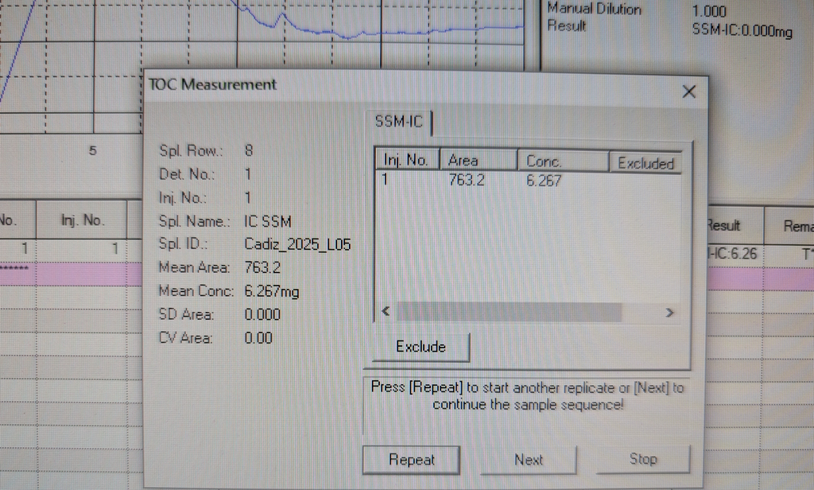

Based on our visual observation, it seemed important for the samples to be sufficiently homogeneous for two reasons. Firstly, more samples can be added to the sample boat if it were homogenised into powder rather than having bits of larger biomatter creating space within. Based on our limited laboratory experience, we found that only about 200-300 mg of incompletely homogenised sample can be placed into the SSM 5000A sample boat, while up to about 800 mg of homogenised sample can be added. Secondly, it was observed for the TC contect combustion that the insufficiently homogenised samples have more leftovers than the homogenised samples (Figure 1.2). This suggests the possibility of either a slower or incomplete combustion, which may affect the measurements.

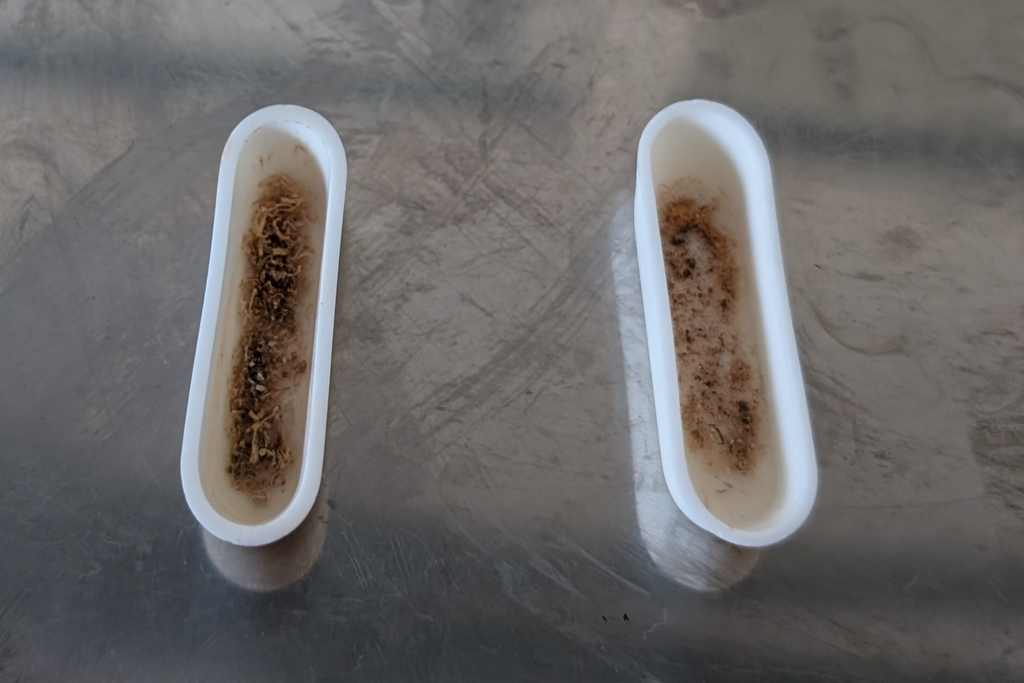

Figure 1.2: Samples post-combustion for the total carbon (TC) content measurement. The sample on the left was not sufficiently homogeneous prior to combustion while the sample on the right was finely ground. The relatively larger pieces of biological matter on the left is still perceivable even after combustion at 900 °C. Furthermore, by visual analysis, its remaining content seems to be more than the homogeneous sample on the right. Do note that this is purely a visual observation based on the sample homogeneity pre-combustion and their corresponding post-combustion state.

Seagrass carbon stock (g C m) was then obtained by first multiplying the TOC with the total sample dry weight, and then dividing with the area of the core (Equations (1.4) and (1.5)).

$$\begin{equation}
Organic\,carbon\,stock\,(g\,C\,m^{-2}) = \frac{TOC \times Total\,sample\,dry\,weight}{Core\,area} \tag{1.4}
\end{equation}$$

$$\begin{equation}
Core\,area\,(m^2) = \pi \times (\frac{0.15}{2})^2 \tag{1.5}
\end{equation}$$

## 1.5 Spatial upscaling

This section will be updated when the mapping work is completed. Total seagrass carbon stock will be derived by applying the seagrass carbon stock equation (1.4) to the seagrass NDVI map.

## 1.6 Uncertainty

$$\begin{equation}
\tau = A \times G_{a} \times (1 - \overline{\sum p}) \tag{1.6}
\end{equation}$$

This section will continue to be updated as the work progresses.

# 2 Results

As there were insufficient remaining samples for the dry weight test, three samples each from Cadiz Bay, the natural and the rewilded site in Ria de Aveiro, and Bourgneuf Bay were tested (Figure 2.1). While the limited sample size hampered the analysis for trends and patterns, the overall range of ratio lies between 0.88 and 0.96 dry weight. Furthermore, the averaged leaf dry weight ratio is 0.937 while the averaged root dry weight ratio is 0.931. Given their closeness, a global average ratio of 0.934 was elected to be generalised across all samples.

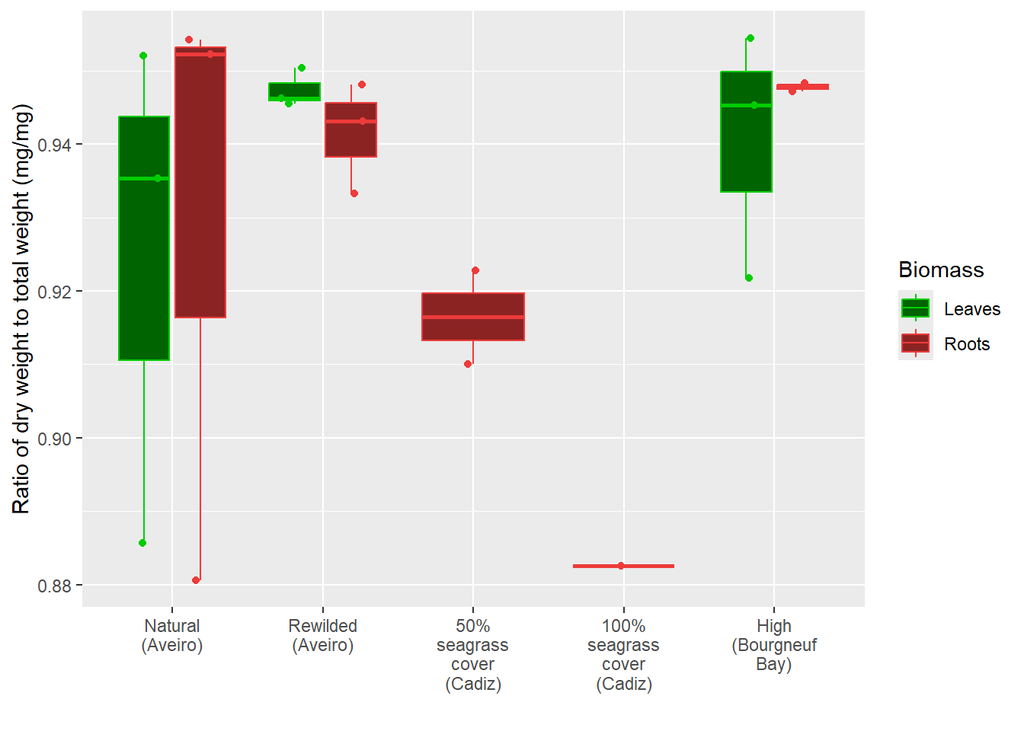

Figure 2.1: Boxplot showing the ratio of dry weight to the total weight of select samples used for the carbon measurement. In spite of keeping the samples in an enclosed container with anhydrous beads, there is still some introduction of atmospheric moisture to the homogeneous sample.

## 2.1 Biomass

Figure 2.2 shows that seagrasses generally have more aboveground biomass than the belowground biomass, with an exception in the 50% seagrass cover condition.

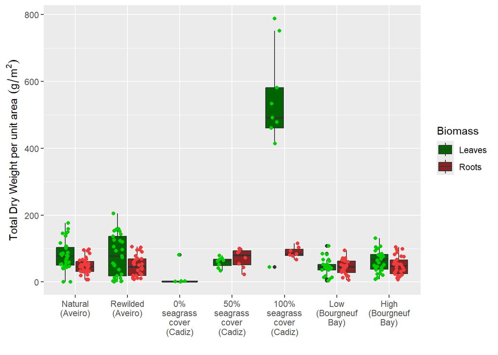

Figure 2.2: Boxplot showing the aboveground and belowground dry weight biomass (g per unit area) of the cores across different conditions. Stations with zero biomass were excluded from the analysis to avoid skewing the boxplots towards zero.

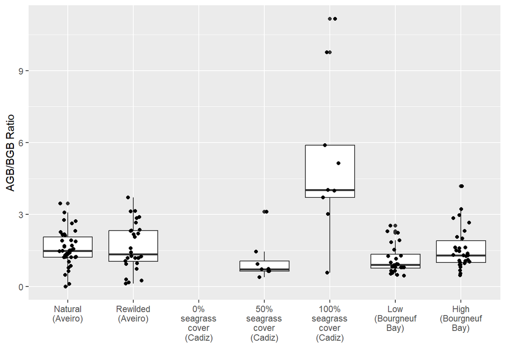

Figure 2.3: Boxplot showing the ratio of aboveground to belowground dry weight biomass (g per unit area) of the cores across different conditions. Stations with zero biomass were naturally excluded from the analysis by virtue of division by zero.

## 2.2 TOC measurement

When classified based on the different station conditions and plotted onto a box plot, it is observed that the leaf carbon content seems to be more in the rewilded site, while the root carbon content seems to be less (Figure 2.4). Similarly, in Cadiz Bay, the carbon content of both the leaves and roots of stations with 100% seagrass cover is more than those from stations with only about 50% seagrass cover.

The F-test shows an equal variance in leaf carbon content between the natural and rewilded sites of Ria de Aveiro (p-value = 0.131), but an unequal variance in the roots and rhizomes carbon content (p-value = 0.0301). Thus, a Student’s t-test was performed for the leaf carbon content comparison while a Welch’s t-Test was performed for the roots and rhizomes carbon content comparison. There is a significant difference in carbon content between the natural and rewilded seagrass for both the leaf (p-value = 0.0119, difference in mean = 0.0135) and roots and rhizomes (p-value = 0.00911, difference in mean = 0.0205).

Similarly, for Cadiz Bay, the F-test shows an equal variance in carbon content between the 50% and 100% seagrass cover sites for the roots and rhizomes (p-value = 0.384), but not for the leaves (p-value = 0.0323). There is a significant difference in carbon content between the 50% and 100% cover meadows for both the leaf (p-value = 0.0109, difference in mean = 0.0718) and roots and rhizomes (p-value = 0.000247, difference in mean = 0.104).

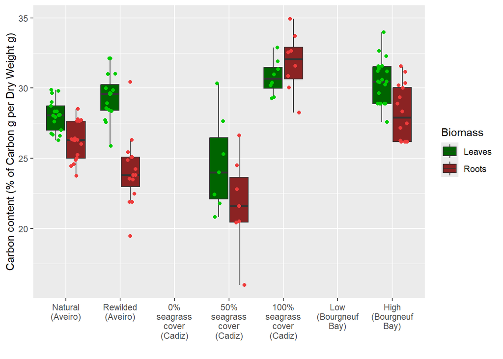

Figure 2.4: Boxplot showing the percent carbon content (C g per dry weight g) in the seagrass above- and belowground biomass in the cores across different conditions. All zero data were removed from the analysis to avoid skewing the boxplot towards zero.

The seagrass carbon stock seemed similar between the natural and rewilded sites in Ria de Aveiro. In Cadiz Bay, the seagrass carbon stock for both the leaves and roots are greater in the 100% seagrass cover stations than the 50% seagrass cover station. Notably, leaf carbon stock is substantially higher than root carbon stocks in the 100% seagrass cover stations (Figure 2.5), which is a natural product (multiplication) of the very high leaf total dry weight per unit area for the 100% cover stations in Cadiz (Figure 2.2).

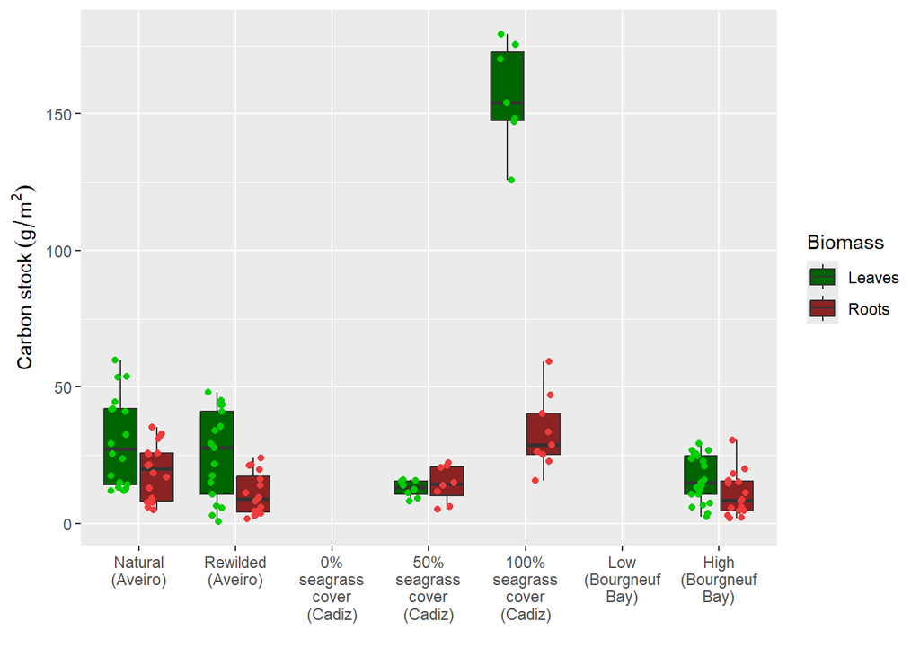

Figure 2.5: Boxplot showing the seagrass aboveground and belowground organic carbon stock (C g per unit area) of the cores across different conditions.

The soil dry bulk density variances of the rewilded and natural sites at Aveiro do not have a similar variance (p-value = 0.0258). Based on the Welch’s t-Test, there were no significant differences between the dry bulk densities at both sites (p-value = 0.427).

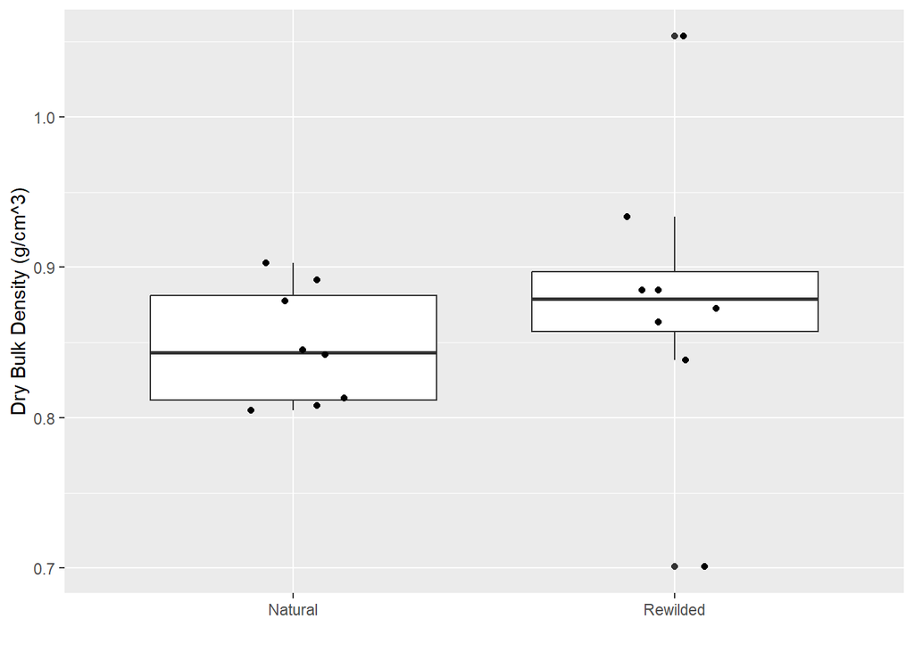

Figure 2.6: Boxplot showing the soil dry bulk density (g/cm3) of the cores across different conditions.

The soil carbon content variances of the rewilded and natural sites at Aveiro have a similar variance (p-value = 0.176), and there were no significant differences between their carbon content across both sites (p-value = 0.328).

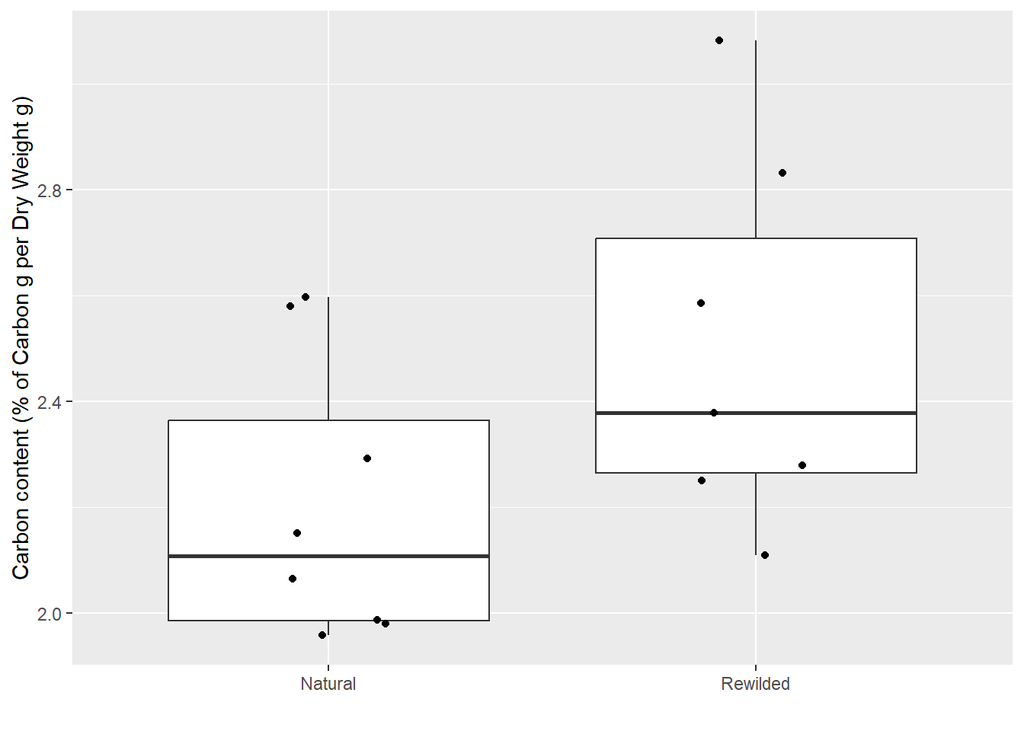

Figure 2.7: Boxplot showing the percent carbon content (C g per dry weight g) of the cores across different conditions.

## 2.3 Spatial upscaling

This section will be updated when the mapping work is completed.

# References

Bargain, A, M Robin, V Méléder, P Rosa, E Le Menn, N Harin, and L Barillé. 2013. “Seasonal Spectral Variation of *Zostera Noltii* and Its Influence on Pigment-Based Vegetation Indices.” *Journal of Experimental Marine Biology and Ecology* 446: 86–94. https://doi.org/10.1016/j.jembe.2013.04.012.

Davies, Bede Ffinian Rowe, Simon Oiry, Mar Roca, Philippe Rosa, Maria Laura Zoffoli, Dimitris Poursanidis, Tobias Dolch, et al. 2026. “An Initial Map of European Intertidal Seagrass.” *Remote Sensing of Environment* 333: 115116.

Davies, Bede Ffinian Rowe, Simon Oiry, Philippe Rosa, Maria Laura Zoffoli, Ana I. Sousa, Oliver R. Thomas, Dan A. Smale, et al. 2024. “Intertidal Seagrass Extent from Sentinel-2 Time-Series Show Distinct Trajectories in Western Europe.” *Remote Sensing of Environment* 312: 114340. https://doi.org/10.1016/j.rse.2024.114340.

R Core Team. 2025. *R: A Language and Environment for Statistical Computing*. Vienna, Austria: R Foundation for Statistical Computing. https://www.R-project.org/.

Zeileis, Achim, and Gabor Grothendieck. 2005. “Zoo: S3 Infrastructure for Regular and Irregular Time Series.” *Journal of Statistical Software* 14 (6): 1–27. https://doi.org/10.18637/jss.v014.i06.

Zoffoli, Maria Laura, Pierre Gernez, Philippe Rosa, Anthony Le Bris, Vittorio E Brando, Anne-Laure Barillé, Nicolas Harin, et al. 2020. “Sentinel-2 Remote Sensing of *Zostera Noltei*-Dominated Intertidal Seagrass Meadows.” *Remote Sensing of Environment* 251: 112020. https://doi.org/10.1016/j.rse.2020.112020.